# Covariant and Contravariant Tensors

### **NOTES ON STATISTICS, PROBABILITY and MATHEMATICS**

### Covariant and Contravariant Tensors:

A concrete explanation can be found [here](https://youtu.be/JY_lUOWClEY), and it proceeds as follows:

We have two inertial (no acceleration) coordinate systems, $S$ and $S'$, where $S'$ moves away from $S$ at constant velocity $v$ *along* the $x$ axis - for now we assume no rotation or movement along the other two axes, $y$ and $z$.

An event $P$ happens and it is recorded in $S$ as $(ct, x, y, z)$. Why $ct$? To express time in the same units as the space coordintes we multiply the velocity of light by the observation of time. Not important.

The same event $P$ will be expressed in relation to the $S'$ coordinates as $P=(ct', x', y',z').$

#### Definition: CONTRAVARIANT VECTOR:

$x^\mu = (x^0,x^1,x^2,x^3)$, such that

$x^0= ct, \quad x^1=x, \quad x^2=y, \quad x^3=z$

So $\mu$ is an index, $\mu= 0,1,2,3.$

#### Definition: COVARIANT VECTOR:

$x_\mu=(x_0,x_1,x_2,x_3)$, such that

$x_0=ct, \quad x_1=\color{red}{-}x, \quad\color{red}{-}y \quad\color{red}{-}z$

Why do we need this?

The contravariant and covariant vectors of the same event in relation to the frame $S'$ are:

$x'^\mu=(x^{'0}, x^{'1},x^{'2},x^{'3})\quad \text{contravariant}$

and

$x'_\mu=(x'_0, x'_1,x'_2,x'_3)\quad\text{covariant}$

Now we have to bring in the Lorentz transformations for the answer to make sense. They are the equations that change coordinates between $S$ and $S'$ taking into consideration time dilation and length contraction (along the $x$ axis only, since the frames are only moving with respect to each other along $x$):

The transformation of time from $t$ in frame $S$ to $t'$ in $S'$ is given by $t' = \gamma \left(t - \frac{v}{c^2}x\right)$; while the transformation of $x$ from $S$ to $S'$ obeys the equation $x' =\gamma(x - vt).$ This is explained [here](https://youtu.be/-O8EO50MyiA), and adopting the notation of contravariant and covariant vectors, and the $ct$ expression of $t$:

$x'^0 = \gamma\left(x^0 - \frac{v}{c} x^1\right)$

$x'^1 = \gamma\left(x^1 - \frac{v}{c} x^0\right)$

$x'^2 = x^2$

$x'^3 = x^3$

Here, $\large\gamma=\frac{1}{\sqrt{1-\frac{v^2}{c^2}}}$. Notice that the third and fourth dimension do not change in this simple model with two frames, one moving along the $x$ axis of the other at constant velocity.

We can express the change in frames in matrix form as:

$$\begin{bmatrix}x'^0\\x'^1\\x'^2\\x'^3\end{bmatrix}=\begin{bmatrix}\gamma&-\gamma\beta&0&0\\-\gamma\beta&\gamma&0&0\\0&0&1&0\\0&0&0&1\end{bmatrix}\begin{bmatrix}x^0\\x^1\\x^2\\x^3\end{bmatrix}$$

with $\beta=\frac{v}{c}.$

If there is motion of $S'$ in more than just the $x$ difrection, the matriceal formula above can be generalized as:

$$\begin{bmatrix}x'^0\\x'^1\\x'^2\\x'^3\end{bmatrix}=\begin{bmatrix}\Lambda^0_{\;
0}&\Lambda^0_{\; 1}&\Lambda^0_{\; 2}&\Lambda^0_{\;
3}\\\Lambda^1_{\; 0}&\Lambda^1_{\; 1}&\Lambda^1_{\;
2}&\Lambda^1_{\; 3}\\\Lambda^2_{\; 0}&\Lambda^2_{\;
1}&\Lambda^2_{\; 2}&\Lambda^2_{\; 3}\\\Lambda^3_{\;
0}&\Lambda^3_{\; 1}&\Lambda^3_{\; 2}&\Lambda^3_{\;
3}\end{bmatrix}\begin{bmatrix}x^0\\x^1\\x^2\\x^3\end{bmatrix}$$

This can be express more succintly as:

$$\color{red}{x'^{\mu} =
\Lambda^\mu_{\; \nu}x^\nu}$$

The same can be done with the covariant vector transformation:

$$\begin{bmatrix}x'_0\\x'_1\\x'_2\\x'_3\end{bmatrix}=\begin{bmatrix}\Lambda_0^{\;
0}&\Lambda_0^{\; 1}&\Lambda_0^{\; 2}&\Lambda_0^{\;
3}\\\Lambda_1^{\; 0}&\Lambda_1^{\; 1}&\Lambda_1^{\;
2}&\Lambda_1^{\; 3}\\\Lambda_2^{\; 0}&\Lambda_2^{\;
1}&\Lambda_2^{\; 2}&\Lambda_2^{\; 3}\\\Lambda_3^{\;
0}&\Lambda_3^{\; 1}&\Lambda_3^{\; 2}&\Lambda_3^{\;
3}\end{bmatrix}\begin{bmatrix}x_0\\x_1\\x_2\\x-3\end{bmatrix}$$

or

$$\color{blue}{x'_{\mu} =
\Lambda_\mu^{\; \nu}x_\nu}$$

The Lorentz transformation $\Lambda$ is defined so that $x'^{\mu}x'_{\mu} = x^\mu x_mu$ (i.e. $\small \text{contravariant in S'} \times \text{covariant in S'}=\text{contravariant in S} \times \text{covariant in S}$).

We can express it as:

$$\Large
\color{red}{x'^{\mu}}\,\color{blue}{x'_{\mu}} = x^\mu \,x_\mu=
\color{red}{\Lambda^\mu_{\;\;\nu}\,x^\nu}\,\color{blue}{\Lambda_\mu^{\;\;\rho}\,x_\rho}=
\Lambda^{\mu}_{\;\;\nu}\,\Lambda_\mu^{\;\;\rho}\,\,x^\nu
\,x_\rho=\delta^\rho_{\;\;\nu}\,x^\nu\,x_\rho$$

Why does it work? Well, when $\rho=\nu=\mu$ the Kronecker product is one, and the final part of the equation above will be $x^\mu\,x_\mu,$ fulfilling the requisite of $x'^{\mu}x'_{\mu} = x^\mu x_\mu.$

Leading to the important result:

$$\large\color{orange}{\Lambda^\mu_{\;\;\nu}\,\Lambda_\mu^{\;\;\rho}=\delta^\rho_{\;\;\nu}}$$

OK. So now we have covariant and contravariant vectors expressing the event with respect to $S$ and $S'$… and Lorentz transformations… we can do this…

$$\large x^\mu x_\mu= x^0 x_0 + x^1 x_1 +
x^2 x_2 + x^3 x_3 = c^2t^2 - \left(x^2 + y^2 + z^2
\right)=\color{red}{c^2t^2 - \vec{x}\vec{x}}$$

$\vec{x}\vec{x}$ is the norm! And the result is a scalar (field value).

How to express this operation generally? We use the Einstein summation convention:

$$A^\mu
B_\mu=A^0B_0+A^1B_1+A^2B_2+A^3B_3$$

where $A^\mu =(A^0,A^1,A^2,A^3)$ has a covariant vector $A_mu=(A_0,A_1,A_2,A_3) = (A_0,-A^1,-A^2,-A^3).$ And so does $B^\mu.$

### Tensors:

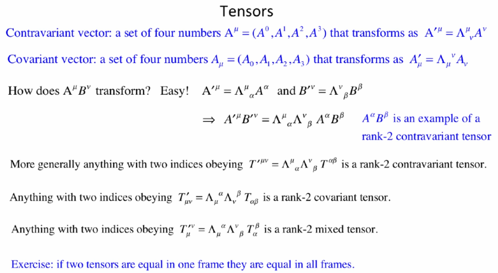

#### Change of Coordinates between Cartesian and Oblique:

From [this video](https://youtu.be/AKPZkHvqTao?list=PL6oNjS6Kc-nTIPkICpvWC1lBEBRsXrIlg).

From [this introductory differential geometry series online](https://youtu.be/AKPZkHvqTao?list=PLD1448E024E04C24D) ushering in the concepts of **contravariant** ($A^i$) and **covariant** ($A_i$) of a vector as a change of coordinates:

In the setting of oblique coordinates, $y$ axis is tilted, but the $x$ axis stays unchanged:

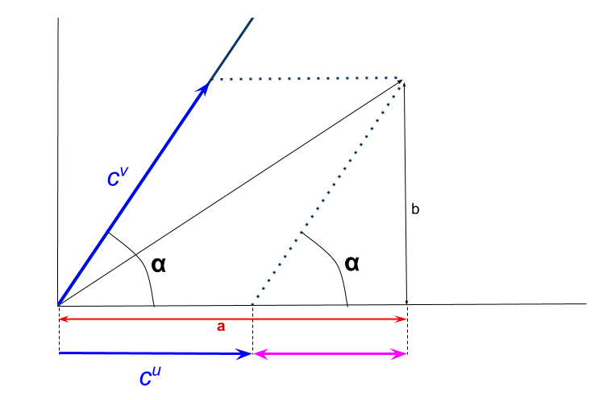

The **contravariant** is calculated as:

Assigning to the pink segment the symbol $*$:

$\text{tan}(\alpha) = \frac{b}{*}$; and therefore, $* = \frac{b}{\text{tan}(\alpha)}$

and $c^u = a - * = a - \frac{b}{\text{tan}(\alpha)}$

while $c^v = \frac{b}{\text{sin}(\alpha)}$

$$H = \begin{bmatrix} 1 & -
\frac{1}{\text{tan}(\alpha)} \\
0 & \frac{1}{\text{sin}(\alpha)}
\end{bmatrix}$$

Therefore,

$$\begin{bmatrix} 1 & -
\frac{1}{\text{tan}(\alpha)} \\
0 & \frac{1}{\text{sin}(\alpha)}
\end{bmatrix}
\begin{bmatrix} c_x \\ c_y
\end{bmatrix}=
\begin{bmatrix} c^u \\ c^v
\end{bmatrix} = \begin{bmatrix} c^1 \\ c^2
\end{bmatrix}$$

and

On the other hand, the **covariant** is calculated as:

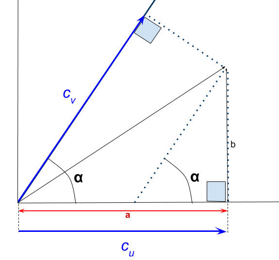

where,

$c_u = a$ and

$\bf c_v = a\,\text{cos}(\alpha) + b\, \text{sin}(\alpha)$

This expression is derived as follows:

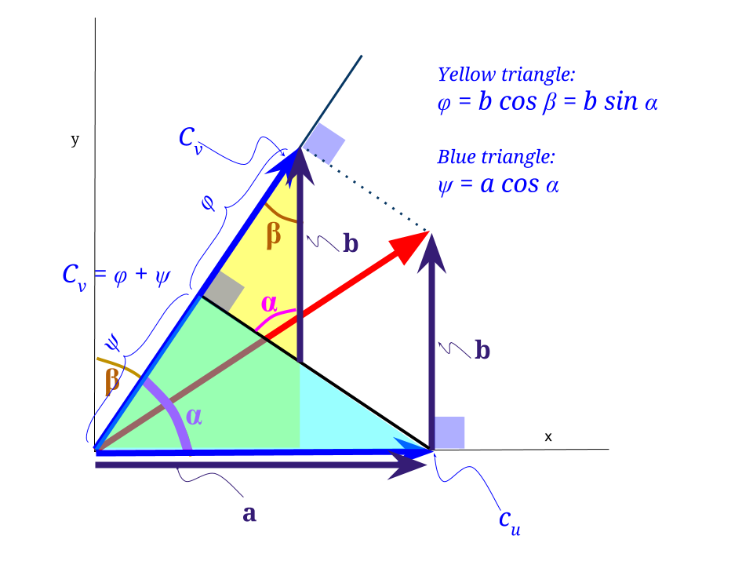

The angles $\alpha$ and $\beta$ are complementary, and $\sin \alpha = \cos \beta$.

$\varphi= b \cos \beta = b \sin \alpha$

$\psi = a \cos \alpha$

$c_v = \psi + \varphi = a \cos \alpha + b \sin \alpha$

It follows that

$$M = \begin{bmatrix} 1 & 0 \\ \cos
\alpha & \sin \alpha \end{bmatrix}$$

Therefore,

$$\begin{bmatrix} 1 & 0 \\
\cos\alpha & \sin \alpha
\end{bmatrix}
\begin{bmatrix} c_x \\ c_y
\end{bmatrix}=
\begin{bmatrix} c_u \\ c_v
\end{bmatrix} = \begin{bmatrix} c_1 \\ c_2
\end{bmatrix}$$

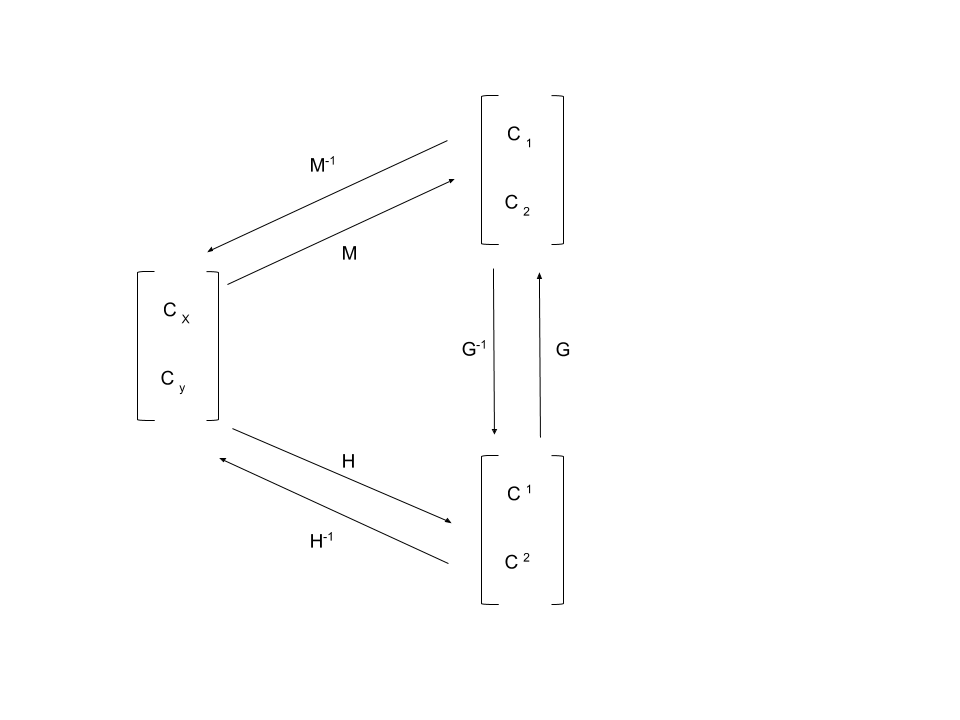

We can prove that the length of a vector in oblique coordinates is **INVARIANT** under the change of coordinates.

$$L^2 = c_x^2 + c_y^2 = c_1\,c^1 +
c_2\,c^2=u_k\,u^k$$

However, when we go from Cartesian to oblique we can’t describe the vector as $A = (A_1,A_2)$ with the length calculated as the norm $A_1^2 + A_2^2$ (or as the dot product). Instead, we need covariant $(A_1,A_2)$ and contravariant $(A^1,A^2)$ components with the length calculated as the dot product (or scalar product) - i.e. $A_1A^1+A_2A^2.$

The Einstein notation is: $g^{ij}\,u_j$, meaning the sum over all the $j$ dimensions.

The “famous” metrix tensor is:

$$dS^2 = g^{ij}\,dx_i\,dx_j= dx^j\,dx_j =
dx^1dx_1 +dx^2dx_2$$

[Home Page](http://rinterested.github.io/statistics/index.html)

**NOTE: These are tentative notes on different topics for personal use - expect mistakes and misunderstandings.**